# 04. Organize Data

DSST289: Introduction to Data Science

Author

Erik Fredner

Published

September 8, 2024

## Verbs

In these notes, we are going to cover a set of functions that take a data frame as an input and return a new version of the data frame. These functions are called **verbs** and come from the `dplyr` package. See the [`dplyr` documentation](https://dplyr.tidyverse.org/) for more information.

If you are familiar with running database queries, note that all of these verbs map onto SQL commands. (If you have no idea what SQL is, don’t worry.) In fact, R can be set up so that `dplyr` is called over a database rather than a local data frame in memory.

There are many verbs in the `dplyr` package, though most are a minor variant or specific application of another verb. In this notebook we will see only some of them:

| Verb | Description |
| --- | --- |
| `slice()` | picks observations based on their positions |
| `select()` | picks variables based on their names |
| `filter()` | picks cases based on their values |
| `arrange()` | changes the ordering of the rows |

In all verb functions, the first argument is the original data frame and the output is a new data frame. Here, we will also see the functions `between` and `%in%` to assist with the filtering command and `desc` (“descending”) to assist with arranging the rows of a data set.

Note that **verbs do not modify the original data**; they operate on a copy of the original data. We have to make an explicit name for the new data set if we want to save it for use elsewhere.

## Choosing rows

### Using `slice`

It is often useful to take a subset of the rows of an existing data set, for example if you want to build a model on a certain subpopulation or highlight a particular part of the data in a plot. Perhaps the most straightforward way to take a subset of rows is to indicate the specific row numbers that we want to extract.

In order to select rows by row numbers, we use the verb `slice`, followed by the numbers of the rows we want separated by commas. Here is an example taking the second, fifth, and seventh rows of the data:

```r
food |>
  slice(2, 5, 7)
```

| item | food_group | calories | total_fat | sat_fat | cholesterol | sodium | carbs | fiber | sugar | protein | iron | vitamin_a | vitamin_c | wiki | description | color |
| --- | --- | --- | --- | --- | --- | --- | --- | --- | --- | --- | --- | --- | --- | --- | --- | --- |
| Asparagus | vegetable | 20 | 0.1 | 0.046 | 0 | 2 | 3.88 | 2.1 | 1.88 | 2.20 | 12 | 15 | 9 | asparagus | Any of various perennial plants of the genus Asparagus having leaflike stems, scalelike leaves, and small flowers. | green |
| Chickpea | grains | 180 | 2.9 | 0.309 | 0 | 243 | 29.98 | 8.6 | 5.29 | 9.54 | 17 | 0 | 3 | chickpea | An annual Asian plant (Cicer arietinum) in the pea family, widely cultivated for the edible seeds in its short inflated pods. | brown |
| Beef | meat | 288 | 19.5 | 7.731 | 87 | 384 | 0.00 | 0.0 | 0.00 | 26.33 | 15 | 0 | 0 | beef | The meat from a cow, bull or other bovine. | red |

As mentioned above, the code here does not change the data set `food` itself. It still has all 61 rows of food contained in it.

If we want to create a new data set with just these three food item, we need to explicitly name and assign it. For example, here is how we would create a data set of the first five food items named `food_first_five`:

```r
food_first_five <- food |>
  slice(1, 2, 3, 4, 5)
```

There is a convenient a shorthand for selecting a range of row numbers, for example every row from the first to the fifth, by indicating the starting and ending row number by a colon: `1:5`.

Here, for example, is another way to select the first five rows of the data set:

```r
food |>
  slice(1:5)
```

| item | food_group | calories | total_fat | sat_fat | cholesterol | sodium | carbs | fiber | sugar | protein | iron | vitamin_a | vitamin_c | wiki | description | color |
| --- | --- | --- | --- | --- | --- | --- | --- | --- | --- | --- | --- | --- | --- | --- | --- | --- |
| Apple | fruit | 52 | 0.1 | 0.028 | 0 | 1 | 13.81 | 2.4 | 10.39 | 0.26 | 1 | 1 | 8 | apple | A common, round fruit produced by the tree Malus domestica, cultivated in temperate climates. | red |
| Asparagus | vegetable | 20 | 0.1 | 0.046 | 0 | 2 | 3.88 | 2.1 | 1.88 | 2.20 | 12 | 15 | 9 | asparagus | Any of various perennial plants of the genus Asparagus having leaflike stems, scalelike leaves, and small flowers. | green |
| Avocado | fruit | 160 | 14.6 | 2.126 | 0 | 7 | 8.53 | 6.7 | 0.66 | 2.00 | 3 | 3 | 17 | avocado | The large, usually yellowish-green or black, pulpy fruit of the avocado tree. | green |
| Banana | fruit | 89 | 0.3 | 0.112 | 0 | 1 | 22.84 | 2.6 | 12.23 | 1.09 | 1 | 1 | 15 | banana | An elongated curved tropical fruit that grows in bunches and has a creamy flesh and a smooth skin. | yellow |
| Chickpea | grains | 180 | 2.9 | 0.309 | 0 | 243 | 29.98 | 8.6 | 5.29 | 9.54 | 17 | 0 | 3 | chickpea | An annual Asian plant (Cicer arietinum) in the pea family, widely cultivated for the edible seeds in its short inflated pods. | brown |

You can of course do this with any range of row numbers:

```r
food |>
  slice(10:15)
```

| item | food_group | calories | total_fat | sat_fat | cholesterol | sodium | carbs | fiber | sugar | protein | iron | vitamin_a | vitamin_c | wiki | description | color |
| --- | --- | --- | --- | --- | --- | --- | --- | --- | --- | --- | --- | --- | --- | --- | --- | --- |
| Broccoli | vegetable | 34 | 0.3 | 0.039 | 0 | 33 | 6.64 | 2.6 | 1.70 | 2.82 | 4 | 12 | 149 | broccoli | A plant, Brassica oleracea var. italica, of the cabbage family, Brassicaceae; especially, the tree-shaped flower and stalk that are eaten as a vegetable. | green |
| Cabbage | vegetable | 24 | 0.1 | 0.016 | 0 | 18 | 5.58 | 2.3 | 3.58 | 1.44 | 3 | 3 | 54 | cabbage | An edible plant (Brassica oleracea var. capitata) having a head of green leaves. | green |
| Cantaloupe | fruit | 34 | 0.1 | 0.051 | 0 | 16 | 8.16 | 0.9 | 7.86 | 0.84 | 1 | 68 | 61 | cantaloupe | A melon of species Cucumis melo subsp. melo with sweet orange flesh, with numerous cultivars in several cultivar groups. | orange |
| Carrot | vegetable | 41 | 0.2 | 0.037 | 0 | 69 | 9.58 | 2.8 | 4.54 | 0.93 | 2 | 336 | 10 | carrot | A vegetable with a nutritious, juicy, sweet root that is often orange in colour, Daucus carota, especially the subspecies sativus in the family Apiaceae. | orange |
| Catfish | fish | 240 | 14.5 | 3.246 | 69 | 398 | 8.54 | 0.5 | 0.85 | 17.57 | 6 | 1 | 1 | catfish | Any fish of the order Siluriformes, mainly found in fresh water, lacking scales, and having barbels like whiskers around the mouth | white |
| Cauliflower | vegetable | 25 | 0.0 | 0.032 | 0 | 30 | 5.30 | 2.5 | 2.40 | 1.98 | 2 | 0 | 77 | cauliflower | Brassica oleracea var. botrytis, an annual variety of cabbage, of which the cluster of young flower stalks and buds is eaten as a vegetable. | white |

### Using `filter`

Another way to take a subset of our data is to select rows based on conditions about the features in the data set. To do this we use the `filter` function, which accepts a statement about features in the data set. Only rows where the statements are `TRUE` will be returned. For example, here is how we use the `filter` command to select the foods that have more than 150 calories in each serving:

```r
food |>
  filter(calories > 150)
```

| item | food_group | calories | total_fat | sat_fat | cholesterol | sodium | carbs | fiber | sugar | protein | iron | vitamin_a | vitamin_c | wiki | description | color |
| --- | --- | --- | --- | --- | --- | --- | --- | --- | --- | --- | --- | --- | --- | --- | --- | --- |
| Avocado | fruit | 160 | 14.6 | 2.126 | 0 | 7 | 8.53 | 6.7 | 0.66 | 2.00 | 3 | 3 | 17 | avocado | The large, usually yellowish-green or black, pulpy fruit of the avocado tree. | green |
| Chickpea | grains | 180 | 2.9 | 0.309 | 0 | 243 | 29.98 | 8.6 | 5.29 | 9.54 | 17 | 0 | 3 | chickpea | An annual Asian plant (Cicer arietinum) in the pea family, widely cultivated for the edible seeds in its short inflated pods. | brown |
| Beef | meat | 288 | 19.5 | 7.731 | 87 | 384 | 0.00 | 0.0 | 0.00 | 26.33 | 15 | 0 | 0 | beef | The meat from a cow, bull or other bovine. | red |
| Catfish | fish | 240 | 14.5 | 3.246 | 69 | 398 | 8.54 | 0.5 | 0.85 | 17.57 | 6 | 1 | 1 | catfish | Any fish of the order Siluriformes, mainly found in fresh water, lacking scales, and having barbels like whiskers around the mouth | white |
| Cheese | dairy | 350 | 26.9 | 16.609 | 83 | 955 | 4.71 | 0.0 | 3.54 | 22.21 | 3 | 16 | 0 | cheese | A dairy product made from curdled or cultured milk. | yellow |
| Chicken | meat | 237 | 13.4 | 3.758 | 87 | 404 | 0.00 | 0.0 | 0.00 | 27.07 | 7 | 3 | 0 | chicken | A domestic fowl, Gallus gallus, especially when young. | white |
| Clam | fish | 180 | 8.0 | 1.601 | 56 | 400 | 11.06 | 0.5 | 0.85 | 14.84 | 80 | 6 | 17 | clam | A bivalve mollusk of many kinds, especially those that are edible; for example the soft-shell clam (Mya arenaria), the hard clam (Mercenaria mercenaria), the sea clam or hen clam (Spisula solidissima)… | white |
| Cod | fish | 211 | 10.8 | 2.218 | 57 | 401 | 8.25 | 0.5 | 0.82 | 19.20 | 5 | 1 | 4 | cod | A sea fish, the Gadus morhua. | white |
| Halibut | fish | 239 | 17.7 | 3.102 | 59 | 103 | 0.00 | 0.0 | 0.00 | 18.42 | 5 | 1 | 0 | halibut | A large flatfish of the genus Hippoglossus, which sometimes leaves the ocean floor and swims vertically. | white |
| Lamb | meat | 292 | 20.7 | 8.756 | 96 | 394 | 0.00 | 0.0 | 0.00 | 24.32 | 10 | 0 | 0 | sheep | A young sheep. | red |

[output cut: 10 more lines]

### `filter(between())`

The function `between` is often useful in combination with `filter`. For example, here are the rows that have between 2 and 3 grams of total fat:

```r
food |>
  filter(between(total_fat, left = 2, right = 3))
```

| item | food_group | calories | total_fat | sat_fat | cholesterol | sodium | carbs | fiber | sugar | protein | iron | vitamin_a | vitamin_c | wiki | description | color |
| --- | --- | --- | --- | --- | --- | --- | --- | --- | --- | --- | --- | --- | --- | --- | --- | --- |
| Chickpea | grains | 180 | 2.9 | 0.309 | 0 | 243 | 29.98 | 8.6 | 5.29 | 9.54 | 17 | 0 | 3 | chickpea | An annual Asian plant (Cicer arietinum) in the pea family, widely cultivated for the edible seeds in its short inflated pods. | brown |
| Quinoa | grains | 143 | 2.2 | 0.226 | 0 | 196 | 26.35 | 2.3 | 0.00 | 5.01 | 20 | 0 | 0 | quinoa | A goosefoot (Chenopodium quinoa) native to the Andes and cultivated for its edible seeds. | brown |
| Shrimp | fish | 144 | 2.3 | 0.446 | 206 | 613 | 1.24 | 0.0 | 0.00 | 27.59 | 16 | 4 | 3 | shrimp | Any of many swimming, often edible crustaceans, chiefly of the infraorder Caridea or the suborder Dendrobranchiata, with slender legs, long whiskers and a long abdomen. | pink |
| Potato | vegetable | 104 | 2.0 | 0.458 | 0 | 254 | 19.36 | 1.7 | 0.82 | 1.66 | 2 | 2 | 12 | potato | A plant tuber, Solanum tuberosum, eaten as a starchy vegetable, particularly in the Americas and Europe. | white |

### Using `%in%`

If you want to filter on a categorical feature (e.g., a name), you can use the `%in%` operator to select specific categories. Here is the code to filter only the fish:

```r
food |>
  filter(food_group %in% "fish")
```

| item | food_group | calories | total_fat | sat_fat | cholesterol | sodium | carbs | fiber | sugar | protein | iron | vitamin_a | vitamin_c | wiki | description | color |
| --- | --- | --- | --- | --- | --- | --- | --- | --- | --- | --- | --- | --- | --- | --- | --- | --- |
| Crab | fish | 87 | 1.0 | 0.222 | 78 | 293 | 0.04 | 0.0 | 0.00 | 18.06 | 4 | 0 | 5 | callinectes_sapidus | A crustacean of the infraorder Brachyura, having five pairs of legs, the foremost of which are in the form of claws, and a carapace. | red |
| Catfish | fish | 240 | 14.5 | 3.246 | 69 | 398 | 8.54 | 0.5 | 0.85 | 17.57 | 6 | 1 | 1 | catfish | Any fish of the order Siluriformes, mainly found in fresh water, lacking scales, and having barbels like whiskers around the mouth | white |
| Clam | fish | 180 | 8.0 | 1.601 | 56 | 400 | 11.06 | 0.5 | 0.85 | 14.84 | 80 | 6 | 17 | clam | A bivalve mollusk of many kinds, especially those that are edible; for example the soft-shell clam (Mya arenaria), the hard clam (Mercenaria mercenaria), the sea clam or hen clam (Spisula solidissima)… | white |
| Cod | fish | 211 | 10.8 | 2.218 | 57 | 401 | 8.25 | 0.5 | 0.82 | 19.20 | 5 | 1 | 4 | cod | A sea fish, the Gadus morhua. | white |
| Flounder | fish | 133 | 4.2 | 0.867 | 56 | 417 | 0.41 | 0.0 | 0.09 | 22.00 | 2 | 3 | 6 | flounder | A European species of flatfish having dull brown colouring with reddish-brown blotches. | white |
| Halibut | fish | 239 | 17.7 | 3.102 | 59 | 103 | 0.00 | 0.0 | 0.00 | 18.42 | 5 | 1 | 0 | halibut | A large flatfish of the genus Hippoglossus, which sometimes leaves the ocean floor and swims vertically. | white |
| Haddock | fish | 128 | 3.7 | 0.690 | 66 | 402 | 0.48 | 0.1 | 0.11 | 22.08 | 7 | 4 | 3 | haddock | A marine fish, Melanogrammus aeglefinus, of the North Atlantic, important as a food fish. | white |
| Lobster | fish | 97 | 0.5 | 0.106 | 71 | 700 | 1.27 | 0.0 | 0.00 | 20.33 | 2 | 2 | 0 | lobster | A crustacean of the Nephropidae family, dark green or blue-black in colour turning bright red when cooked, with a hard shell and claws, which is used as a seafood. | red |
| Oyster | fish | 160 | 7.9 | 1.848 | 57 | 595 | 12.54 | 0.5 | 0.71 | 9.08 | 43 | 5 | 6 | oyster | Any of certain marine bivalve mollusks, especially those of the family Ostreidae (the true oysters), usually found adhering to rocks or other fixed objects in shallow water along the seacoasts, or in … | white |
| Salmon | fish | 171 | 7.5 | 1.312 | 62 | 467 | 0.49 | 0.0 | 0.11 | 23.97 | 5 | 5 | 4 | salmon | One of several species of fish, typically of the Salmoninae subfamily, brownish above with silvery sides and delicate pinkish-orange flesh; they ascend rivers to spawn. | pink |

[output cut: 4 more lines]

If you wanted to select multiple categories, you can pass a vector of strings using the `c()` function, which *concatenates* multiple strings together.

```r
food |>
  # `filter` for fish AND meat with `c`:
  filter(food_group %in% c("fish", "meat"))
```

| item | food_group | calories | total_fat | sat_fat | cholesterol | sodium | carbs | fiber | sugar | protein | iron | vitamin_a | vitamin_c | wiki | description | color |
| --- | --- | --- | --- | --- | --- | --- | --- | --- | --- | --- | --- | --- | --- | --- | --- | --- |
| Beef | meat | 288 | 19.5 | 7.731 | 87 | 384 | 0.00 | 0.0 | 0.00 | 26.33 | 15 | 0 | 0 | beef | The meat from a cow, bull or other bovine. | red |
| Crab | fish | 87 | 1.0 | 0.222 | 78 | 293 | 0.04 | 0.0 | 0.00 | 18.06 | 4 | 0 | 5 | callinectes_sapidus | A crustacean of the infraorder Brachyura, having five pairs of legs, the foremost of which are in the form of claws, and a carapace. | red |
| Catfish | fish | 240 | 14.5 | 3.246 | 69 | 398 | 8.54 | 0.5 | 0.85 | 17.57 | 6 | 1 | 1 | catfish | Any fish of the order Siluriformes, mainly found in fresh water, lacking scales, and having barbels like whiskers around the mouth | white |
| Chicken | meat | 237 | 13.4 | 3.758 | 87 | 404 | 0.00 | 0.0 | 0.00 | 27.07 | 7 | 3 | 0 | chicken | A domestic fowl, Gallus gallus, especially when young. | white |
| Clam | fish | 180 | 8.0 | 1.601 | 56 | 400 | 11.06 | 0.5 | 0.85 | 14.84 | 80 | 6 | 17 | clam | A bivalve mollusk of many kinds, especially those that are edible; for example the soft-shell clam (Mya arenaria), the hard clam (Mercenaria mercenaria), the sea clam or hen clam (Spisula solidissima)… | white |
| Cod | fish | 211 | 10.8 | 2.218 | 57 | 401 | 8.25 | 0.5 | 0.82 | 19.20 | 5 | 1 | 4 | cod | A sea fish, the Gadus morhua. | white |
| Duck | meat | 132 | 5.9 | 2.320 | 77 | 74 | 0.00 | 0.0 | 0.00 | 18.28 | 13 | 2 | 10 | duck | An aquatic bird of the family Anatidae, having a flat bill and webbed feet. | red |
| Flounder | fish | 133 | 4.2 | 0.867 | 56 | 417 | 0.41 | 0.0 | 0.09 | 22.00 | 2 | 3 | 6 | flounder | A European species of flatfish having dull brown colouring with reddish-brown blotches. | white |
| Halibut | fish | 239 | 17.7 | 3.102 | 59 | 103 | 0.00 | 0.0 | 0.00 | 18.42 | 5 | 1 | 0 | halibut | A large flatfish of the genus Hippoglossus, which sometimes leaves the ocean floor and swims vertically. | white |
| Haddock | fish | 128 | 3.7 | 0.690 | 66 | 402 | 0.48 | 0.1 | 0.11 | 22.08 | 7 | 4 | 3 | haddock | A marine fish, Melanogrammus aeglefinus, of the North Atlantic, important as a food fish. | white |

[output cut: 10 more lines]

## Chaining verbs together

As with other verbs and other pipe `|>` examples we have seen, we can chain together multiple calls to produce more complex logic. For example, this code selects fruits that have more than 150 calories per serving:

```r
food |>
  filter(calories > 150) |>
  filter(food_group %in% "fruit")
```

| item | food_group | calories | total_fat | sat_fat | cholesterol | sodium | carbs | fiber | sugar | protein | iron | vitamin_a | vitamin_c | wiki | description | color |
| --- | --- | --- | --- | --- | --- | --- | --- | --- | --- | --- | --- | --- | --- | --- | --- | --- |
| Avocado | fruit | 160 | 14.6 | 2.126 | 0 | 7 | 8.53 | 6.7 | 0.66 | 2 | 3 | 3 | 17 | avocado | The large, usually yellowish-green or black, pulpy fruit of the avocado tree. | green |

Which results in a reduced data set with only 1 row (avocados).

### Exact matches `==` and `!=`

You can also test whether features are equal using `==` (e.g., `food_group == "fruit"`). Or you can test for inequality, (e.g., `food_group != "fruit"`).

**Stop Scrolling**

Before looking at the output of the code below, can you guess what it will be?

```r
food |>
  filter(food_group != "fruit") |>
  filter(food_group == "fruit")
```

| item | food_group | calories | total_fat | sat_fat | cholesterol | sodium | carbs | fiber | sugar | protein | iron | vitamin_a | vitamin_c | wiki | description | color |
| --- | --- | --- | --- | --- | --- | --- | --- | --- | --- | --- | --- | --- | --- | --- | --- | --- |

If you don’t understand why this outputs zero rows, re-read this section.

## Combining `filter` with `ggplot`

It is also possible to create a chain of calls that then get piped into a call to the `ggplot` function. For example, here is a plot of the fruits and vegetables with the Avocado outlier removed (by limiting the maximum available total fat).

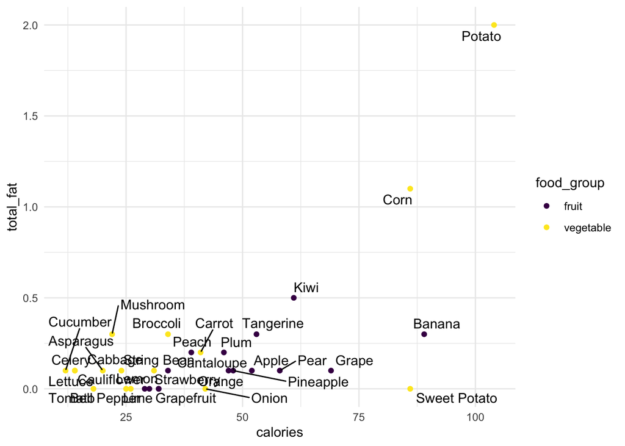

```r
food |>
  # remember that you pipe |> between verbs
  filter(food_group %in% c("vegetable", "fruit")) |>
  filter(total_fat < 10) |>
  # but add + layers to ggplot
  ggplot() +
  geom_point(aes(x = calories, y = total_fat, color = food_group)) +
  geom_text_repel(aes(x = calories, y = total_fat, label = item)) +
  scale_color_viridis_d()
```

The pattern of a starting with a data set, applying a number of transformations, and then creating a visualization of the data will become a common pattern in our analyses.

## Data and Layers

Now that we know how to create a subset of our data, let’s use this new knowledge to build some interesting data visualizations. To start, create a data set that just consists of the food types that are in the meat food group:

```r
food_meat <- filter(food, food_group %in% "meat")
food_meat
```

| item | food_group | calories | total_fat | sat_fat | cholesterol | sodium | carbs | fiber | sugar | protein | iron | vitamin_a | vitamin_c | wiki | description | color |
| --- | --- | --- | --- | --- | --- | --- | --- | --- | --- | --- | --- | --- | --- | --- | --- | --- |
| Beef | meat | 288 | 19.5 | 7.731 | 87 | 384 | 0 | 0 | 0 | 26.33 | 15 | 0 | 0 | beef | The meat from a cow, bull or other bovine. | red |
| Chicken | meat | 237 | 13.4 | 3.758 | 87 | 404 | 0 | 0 | 0 | 27.07 | 7 | 3 | 0 | chicken | A domestic fowl, Gallus gallus, especially when young. | white |
| Duck | meat | 132 | 5.9 | 2.320 | 77 | 74 | 0 | 0 | 0 | 18.28 | 13 | 2 | 10 | duck | An aquatic bird of the family Anatidae, having a flat bill and webbed feet. | red |
| Lamb | meat | 292 | 20.7 | 8.756 | 96 | 394 | 0 | 0 | 0 | 24.32 | 10 | 0 | 0 | sheep | A young sheep. | red |
| Pork | meat | 271 | 17.0 | 6.168 | 90 | 384 | 0 | 0 | 0 | 27.34 | 6 | 1 | 1 | pork | The meat of a pig; swineflesh. | white |
| Turkey | meat | 187 | 7.0 | 1.999 | 77 | 69 | 0 | 0 | 0 | 28.90 | 8 | 0 | 0 | turkey_(bird) | Either of two species of bird in the genus Meleagris with fan-shaped tails and wattled necks. | white |

One of the core ideas behind the Grammar of Graphics is that complex visualizations can be constructed by layering relatively simply elements on top of one another.

What if we wanted to put together two layers where one layer uses the `food` data set and the other uses `food_meat`? To do this, we can **override** the default data set in a layer with the option `data =`. This will use a different data set within a particular layer. For example, here is how we can layer the meat data set on top of the rest of the food items.

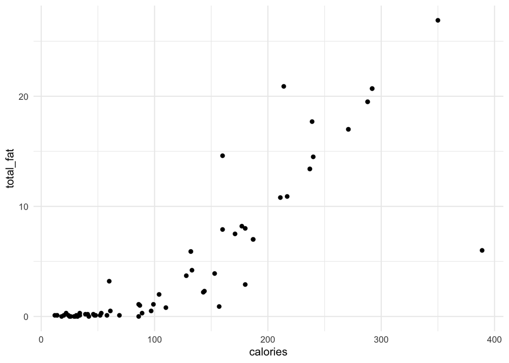

```r
food |>
  ggplot() +
  geom_point(aes(x = calories, y = total_fat)) +
  # note `data =` specifies the data for this layer:
  geom_point(aes(x = calories, y = total_fat), data = food_meat)
```

This plot, however, does not look any different than it would if we were just to plot all of the food together. The second layer of points just sits unassumingly on top of the rest of the data. To rectify this, we can color each layer a different color in order to distinguish them from one another. Let’s try to highlight the meat food group in a navy blue, while making the rest of the points a light grey:

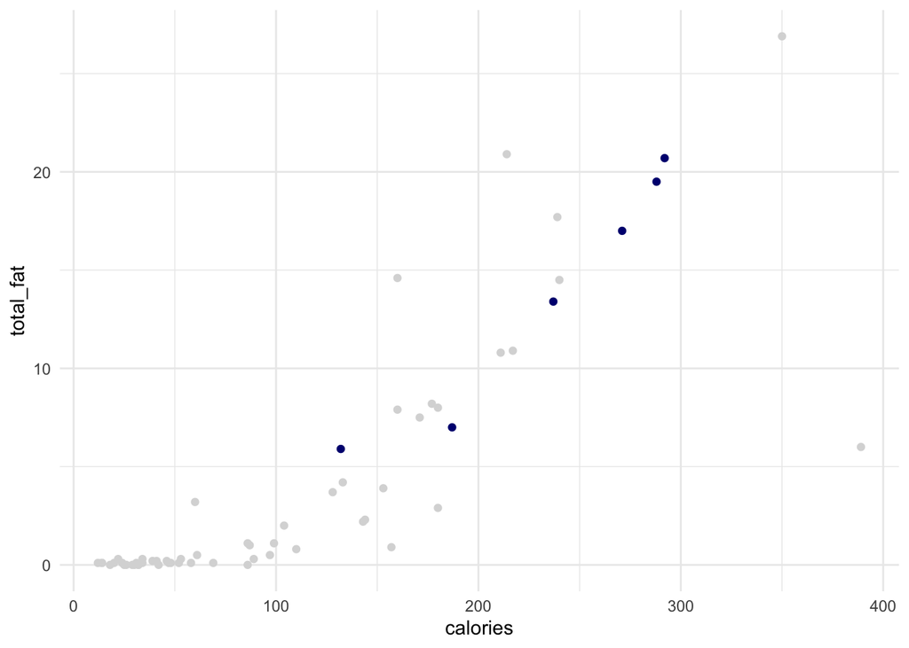

```r
food |>
  ggplot() +
  geom_point(aes(x = calories, y = total_fat), color = "grey85") +
  geom_point(aes(x = calories, y = total_fat), color = "navy", data = food_meat)
```

We now have a plot that shows exactly where the meats are relative to the other food items. We can further build up the plot by showing the names of just these rows of the data set as well:

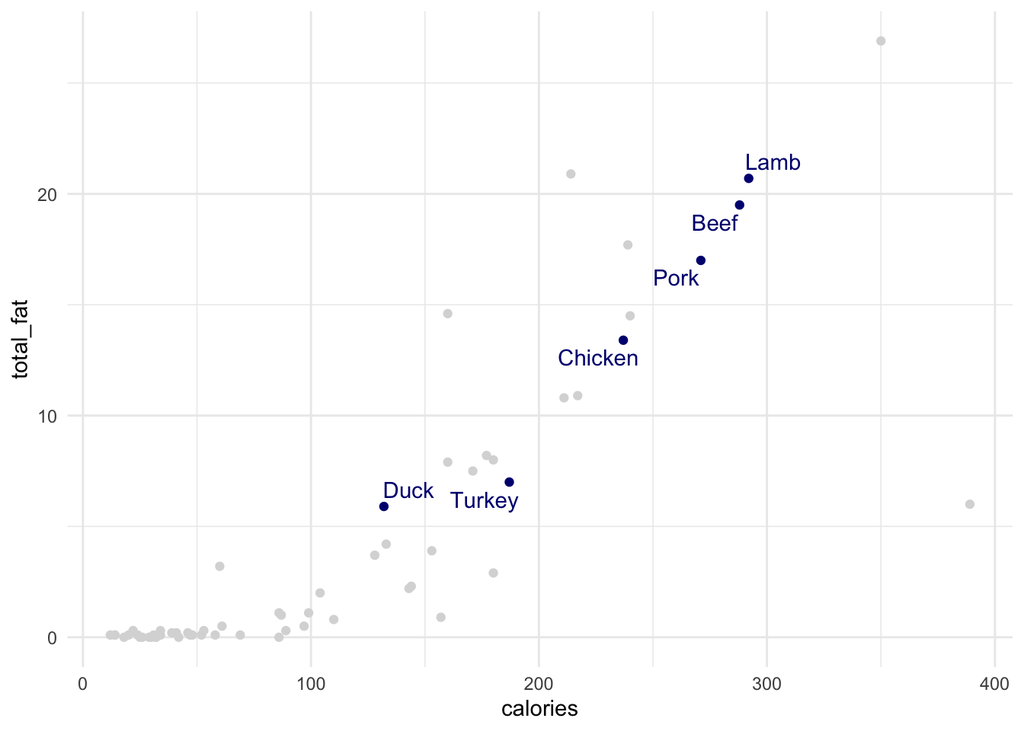

```r
food |>
  ggplot() +
  geom_point(aes(x = calories, y = total_fat), color = "grey85") +
  geom_point(aes(x = calories, y = total_fat), color = "navy", data = food_meat) +
  geom_text_repel(
    aes(x = calories, y = total_fat, label = item),
    color = "navy",
    data = food_meat
  )
```

### Inheriting aesthetics

Notice that the code is starting to get a bit more complicated and some of the graphic layers are becoming a bit long. This is a good place to use the shorthand notation to inherit aesthetics across layers, like this:

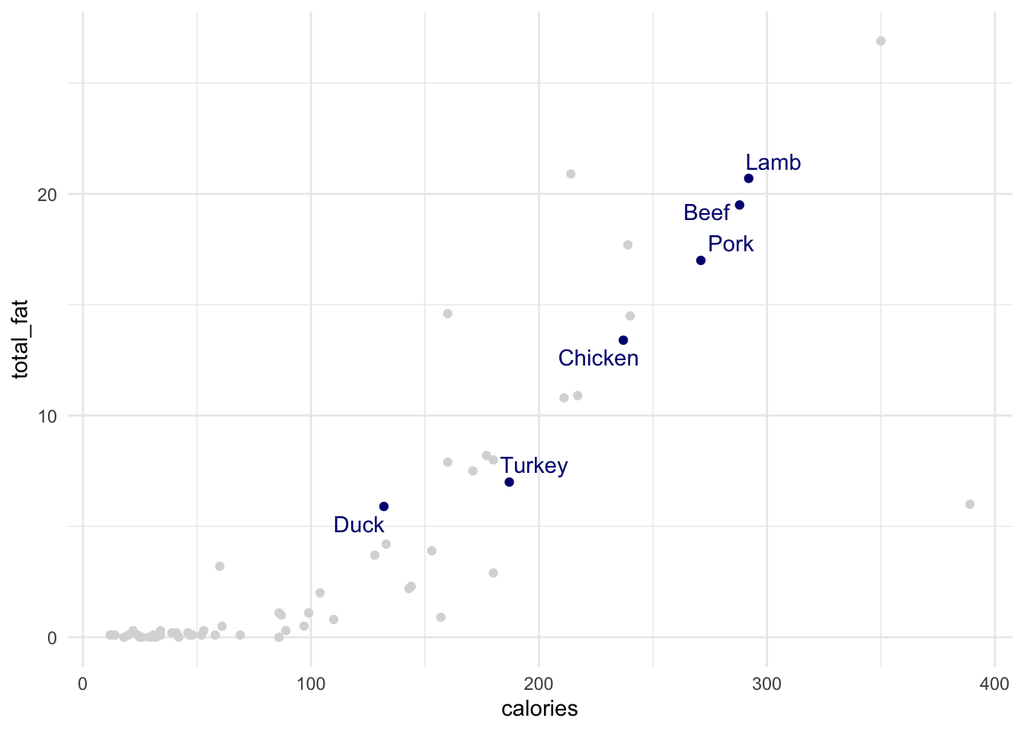

```r
food |>
  # note the assignment of our x and y values in the `ggplot` call:
  ggplot(aes(x = calories, y = total_fat)) +
  geom_point(color = "grey85") +
  geom_point(color = "navy", data = food_meat) +
  geom_text_repel(aes(label = item), color = "navy", data = food_meat)
```

Notice how a relatively small set of commands can be put together in different ways to build a variety of plots. Already, we are making further progress towards building informative and beautiful graphics in R!

## `select`-ing columns

It is also possible to take a subset of the columns in a data set. To do this, we make use of the verb `select`. We pass it the names of the features we want to keep in the output data set, in the (possibly new) order that we want the columns to be arranged in. Here, for example, is a new version of the foods data set containing only the food item name followed by the amount of Vitamin A and Vitamin C:

```r
food |>
  select(item, vitamin_a, vitamin_c)
```

| item | vitamin_a | vitamin_c |
| --- | --- | --- |
| Apple | 1 | 8 |
| Asparagus | 15 | 9 |
| Avocado | 3 | 17 |
| Banana | 1 | 15 |
| Chickpea | 0 | 3 |
| String Bean | 14 | 27 |
| Beef | 0 | 0 |
| Bell Pepper | 63 | 317 |
| Crab | 0 | 5 |
| Broccoli | 12 | 149 |

[output cut: 51 more lines]

## `arrange`-ing Rows

The verbs `slice` and `filter` determine a subset of rows to keep from the original data set. The `arrange` verb, in contrast, keeps all of the original data but re-orders its rows.

Let’s look at `food` as it appears by default:

```r
food
```

| item | food_group | calories | total_fat | sat_fat | cholesterol | sodium | carbs | fiber | sugar | protein | iron | vitamin_a | vitamin_c | wiki | description | color |
| --- | --- | --- | --- | --- | --- | --- | --- | --- | --- | --- | --- | --- | --- | --- | --- | --- |
| Apple | fruit | 52 | 0.1 | 0.028 | 0 | 1 | 13.81 | 2.4 | 10.39 | 0.26 | 1 | 1 | 8 | apple | A common, round fruit produced by the tree Malus domestica, cultivated in temperate climates. | red |
| Asparagus | vegetable | 20 | 0.1 | 0.046 | 0 | 2 | 3.88 | 2.1 | 1.88 | 2.20 | 12 | 15 | 9 | asparagus | Any of various perennial plants of the genus Asparagus having leaflike stems, scalelike leaves, and small flowers. | green |
| Avocado | fruit | 160 | 14.6 | 2.126 | 0 | 7 | 8.53 | 6.7 | 0.66 | 2.00 | 3 | 3 | 17 | avocado | The large, usually yellowish-green or black, pulpy fruit of the avocado tree. | green |
| Banana | fruit | 89 | 0.3 | 0.112 | 0 | 1 | 22.84 | 2.6 | 12.23 | 1.09 | 1 | 1 | 15 | banana | An elongated curved tropical fruit that grows in bunches and has a creamy flesh and a smooth skin. | yellow |
| Chickpea | grains | 180 | 2.9 | 0.309 | 0 | 243 | 29.98 | 8.6 | 5.29 | 9.54 | 17 | 0 | 3 | chickpea | An annual Asian plant (Cicer arietinum) in the pea family, widely cultivated for the edible seeds in its short inflated pods. | brown |
| String Bean | vegetable | 31 | 0.1 | 0.026 | 0 | 6 | 7.13 | 3.4 | 1.40 | 1.82 | 6 | 14 | 27 | green_bean | A long, slender variety of green bean. | green |
| Beef | meat | 288 | 19.5 | 7.731 | 87 | 384 | 0.00 | 0.0 | 0.00 | 26.33 | 15 | 0 | 0 | beef | The meat from a cow, bull or other bovine. | red |
| Bell Pepper | vegetable | 26 | 0.0 | 0.059 | 0 | 2 | 6.03 | 2.0 | 4.20 | 0.99 | 2 | 63 | 317 | bell_pepper | Capsicum annuum, an edible spicy-sweet fruit, originating in the New World. | green |
| Crab | fish | 87 | 1.0 | 0.222 | 78 | 293 | 0.04 | 0.0 | 0.00 | 18.06 | 4 | 0 | 5 | callinectes_sapidus | A crustacean of the infraorder Brachyura, having five pairs of legs, the foremost of which are in the form of claws, and a carapace. | red |
| Broccoli | vegetable | 34 | 0.3 | 0.039 | 0 | 33 | 6.64 | 2.6 | 1.70 | 2.82 | 4 | 12 | 149 | broccoli | A plant, Brassica oleracea var. italica, of the cabbage family, Brassicaceae; especially, the tree-shaped flower and stalk that are eaten as a vegetable. | green |

[output cut: 51 more lines]

Now let’s `arrange` it by `calories`:

```r
food |>
  arrange(calories)
```

| item | food_group | calories | total_fat | sat_fat | cholesterol | sodium | carbs | fiber | sugar | protein | iron | vitamin_a | vitamin_c | wiki | description | color |
| --- | --- | --- | --- | --- | --- | --- | --- | --- | --- | --- | --- | --- | --- | --- | --- | --- |
| Cucumber | vegetable | 12 | 0.1 | 0.013 | 0 | 2 | 2.16 | 0.7 | 1.38 | 0.59 | 1 | 1 | 5 | cucumber | A vine in the gourd family, Cucumis sativus. | green |
| Celery | vegetable | 14 | 0.1 | 0.043 | 0 | 80 | 2.97 | 1.6 | 1.83 | 0.69 | 1 | 9 | 5 | celery | A European herb (Apium graveolens) of the carrot family. | green |
| Lettuce | vegetable | 14 | 0.1 | 0.018 | 0 | 10 | 2.97 | 1.2 | 1.76 | 0.90 | 2 | 10 | 5 | lettuce | An edible plant, Lactuca sativa and its close relatives, having a head of green and/or purple leaves. | green |
| Tomato | vegetable | 18 | 0.0 | 0.046 | 0 | 5 | 3.92 | 1.2 | 2.63 | 0.88 | 2 | 17 | 21 | tomato | A widely cultivated plant, Solanum lycopersicum, having edible fruit. | red |
| Asparagus | vegetable | 20 | 0.1 | 0.046 | 0 | 2 | 3.88 | 2.1 | 1.88 | 2.20 | 12 | 15 | 9 | asparagus | Any of various perennial plants of the genus Asparagus having leaflike stems, scalelike leaves, and small flowers. | green |
| Mushroom | vegetable | 22 | 0.3 | 0.050 | 0 | 5 | 3.28 | 1.0 | 1.65 | 3.09 | 3 | 0 | 4 | mushroom | Any of the fleshy fruiting bodies of fungi typically produced above ground on soil or on their food sources (such as decaying wood). | brown |
| Cabbage | vegetable | 24 | 0.1 | 0.016 | 0 | 18 | 5.58 | 2.3 | 3.58 | 1.44 | 3 | 3 | 54 | cabbage | An edible plant (Brassica oleracea var. capitata) having a head of green leaves. | green |
| Cauliflower | vegetable | 25 | 0.0 | 0.032 | 0 | 30 | 5.30 | 2.5 | 2.40 | 1.98 | 2 | 0 | 77 | cauliflower | Brassica oleracea var. botrytis, an annual variety of cabbage, of which the cluster of young flower stalks and buds is eaten as a vegetable. | white |
| Bell Pepper | vegetable | 26 | 0.0 | 0.059 | 0 | 2 | 6.03 | 2.0 | 4.20 | 0.99 | 2 | 63 | 317 | bell_pepper | Capsicum annuum, an edible spicy-sweet fruit, originating in the New World. | green |
| Lemon | fruit | 29 | 0.0 | 0.039 | 0 | 2 | 9.32 | 2.8 | 2.50 | 1.10 | 3 | 0 | 88 | lemon | A yellowish citrus fruit. | yellow |

[output cut: 51 more lines]

It sorts the data from the smallest to the largest by default.

If we want to sort the data in the opposite direction, we can use the function `desc`, which stands for “descending order:”

```r
food |>
  arrange(desc(calories))
```

| item | food_group | calories | total_fat | sat_fat | cholesterol | sodium | carbs | fiber | sugar | protein | iron | vitamin_a | vitamin_c | wiki | description | color |
| --- | --- | --- | --- | --- | --- | --- | --- | --- | --- | --- | --- | --- | --- | --- | --- | --- |
| Oat | grains | 389 | 6.0 | 1.217 | 0 | 2 | 66.27 | 10.6 | 0.00 | 16.89 | 26 | 0 | 0 | oat | Widely cultivated cereal grass, typically Avena sativa. | brown |
| Cheese | dairy | 350 | 26.9 | 16.609 | 83 | 955 | 4.71 | 0.0 | 3.54 | 22.21 | 3 | 16 | 0 | cheese | A dairy product made from curdled or cultured milk. | yellow |
| Lamb | meat | 292 | 20.7 | 8.756 | 96 | 394 | 0.00 | 0.0 | 0.00 | 24.32 | 10 | 0 | 0 | sheep | A young sheep. | red |
| Beef | meat | 288 | 19.5 | 7.731 | 87 | 384 | 0.00 | 0.0 | 0.00 | 26.33 | 15 | 0 | 0 | beef | The meat from a cow, bull or other bovine. | red |
| Pork | meat | 271 | 17.0 | 6.168 | 90 | 384 | 0.00 | 0.0 | 0.00 | 27.34 | 6 | 1 | 1 | pork | The meat of a pig; swineflesh. | white |
| Catfish | fish | 240 | 14.5 | 3.246 | 69 | 398 | 8.54 | 0.5 | 0.85 | 17.57 | 6 | 1 | 1 | catfish | Any fish of the order Siluriformes, mainly found in fresh water, lacking scales, and having barbels like whiskers around the mouth | white |
| Halibut | fish | 239 | 17.7 | 3.102 | 59 | 103 | 0.00 | 0.0 | 0.00 | 18.42 | 5 | 1 | 0 | halibut | A large flatfish of the genus Hippoglossus, which sometimes leaves the ocean floor and swims vertically. | white |
| Chicken | meat | 237 | 13.4 | 3.758 | 87 | 404 | 0.00 | 0.0 | 0.00 | 27.07 | 7 | 3 | 0 | chicken | A domestic fowl, Gallus gallus, especially when young. | white |
| Scallop | fish | 217 | 10.9 | 2.216 | 54 | 487 | 10.49 | 0.5 | 0.82 | 18.14 | 5 | 2 | 4 | scallop | Any of various marine bivalve molluscs of the family Pectinidae which are free-swimming. | white |
| Sour Cream | dairy | 214 | 20.9 | 13.047 | 44 | 53 | 4.27 | 0.0 | 0.16 | 3.16 | 0 | 13 | 2 | sour_cream | Cream which has been treated with a benign bacterium to turn it slightly sour, often used as a condiment, or a topping for baked potatoes. | white |

[output cut: 51 more lines]

### `arrange` by multiple features

If we give `arrange` one or more feature names, it sorts the data by the first feature from smallest to largest (or alphabetically for character features). In the case of ties, the second feature is used if given. More features can be given to further break additional ties. Here is an example where we order the data set first by `food_group` and then by `calories`:

```r
food |>
  arrange(food_group, calories)
```

| item | food_group | calories | total_fat | sat_fat | cholesterol | sodium | carbs | fiber | sugar | protein | iron | vitamin_a | vitamin_c | wiki | description | color |
| --- | --- | --- | --- | --- | --- | --- | --- | --- | --- | --- | --- | --- | --- | --- | --- | --- |
| Milk | dairy | 60 | 3.2 | 1.865 | 10 | 40 | 4.52 | 0.0 | 5.26 | 3.22 | 0 | 2 | 0 | milk | A white liquid produced by the mammary glands of female mammals to nourish their young. | white |
| Yogurt | dairy | 99 | 1.1 | 0.742 | 5 | 53 | 18.64 | 0.0 | 18.64 | 3.98 | 0 | 1 | 1 | yogurt | A milk-based product stiffened by a bacterium-aided curdling process, and sometimes mixed with fruit or other flavoring. | white |
| Sour Cream | dairy | 214 | 20.9 | 13.047 | 44 | 53 | 4.27 | 0.0 | 0.16 | 3.16 | 0 | 13 | 2 | sour_cream | Cream which has been treated with a benign bacterium to turn it slightly sour, often used as a condiment, or a topping for baked potatoes. | white |
| Cheese | dairy | 350 | 26.9 | 16.609 | 83 | 955 | 4.71 | 0.0 | 3.54 | 22.21 | 3 | 16 | 0 | cheese | A dairy product made from curdled or cultured milk. | yellow |
| Crab | fish | 87 | 1.0 | 0.222 | 78 | 293 | 0.04 | 0.0 | 0.00 | 18.06 | 4 | 0 | 5 | callinectes_sapidus | A crustacean of the infraorder Brachyura, having five pairs of legs, the foremost of which are in the form of claws, and a carapace. | red |
| Lobster | fish | 97 | 0.5 | 0.106 | 71 | 700 | 1.27 | 0.0 | 0.00 | 20.33 | 2 | 2 | 0 | lobster | A crustacean of the Nephropidae family, dark green or blue-black in colour turning bright red when cooked, with a hard shell and claws, which is used as a seafood. | red |
| Haddock | fish | 128 | 3.7 | 0.690 | 66 | 402 | 0.48 | 0.1 | 0.11 | 22.08 | 7 | 4 | 3 | haddock | A marine fish, Melanogrammus aeglefinus, of the North Atlantic, important as a food fish. | white |
| Flounder | fish | 133 | 4.2 | 0.867 | 56 | 417 | 0.41 | 0.0 | 0.09 | 22.00 | 2 | 3 | 6 | flounder | A European species of flatfish having dull brown colouring with reddish-brown blotches. | white |
| Shrimp | fish | 144 | 2.3 | 0.446 | 206 | 613 | 1.24 | 0.0 | 0.00 | 27.59 | 16 | 4 | 3 | shrimp | Any of many swimming, often edible crustaceans, chiefly of the infraorder Caridea or the suborder Dendrobranchiata, with slender legs, long whiskers and a long abdomen. | pink |
| Tuna | fish | 153 | 3.9 | 0.811 | 53 | 366 | 0.41 | 0.0 | 0.09 | 27.30 | 5 | 3 | 4 | tuna | Any of several species of fish of the genus Thunnus in the family Scombridae. | red |

[output cut: 51 more lines]

In the new data set all of the dairy products come up first followed by the fish products. Within each group, the items are sorted from the lowest to highest number of calories.

## `arrange` and `slice`

One particularly useful application of `arrange` is to pair it with the verb `slice`. Here, for example, is the code to select the six foods in our data set that have the highest amount of Vitamin A:

```r
food |>
  # get the highest amounts of Vitamin A:
  arrange(desc(vitamin_a)) |>
  # and then take the top six:
  slice(1:6) |>
  select(item, calories, vitamin_a)
```

| item | calories | vitamin_a |
| --- | --- | --- |
| Carrot | 41 | 336 |
| Sweet Potato | 86 | 284 |
| Cantaloupe | 34 | 68 |
| Bell Pepper | 26 | 63 |
| Grapefruit | 32 | 19 |
| Tomato | 18 | 17 |

By saving this data set, we could highlight these specific foods on top of a plot comparing them to the remainder of the data.

## Homework Questions

Consider the following subset of the `hans` data set we worked with in the previous notebook:

| country | continent | life_exp | gdp |
| --- | --- | --- | --- |
| Canada | Americas | 80.653 | 36319.24 |
| France | Europe | 80.657 | 30470.02 |
| Ireland | Europe | 78.885 | 40676.00 |
| Netherlands | Europe | 79.762 | 36797.93 |
| Portugal | Europe | 78.098 | 20509.65 |
| Spain | Europe | 80.941 | 28821.06 |
| United States | Americas | 78.242 | 42951.65 |

For each of the following five questions, write R code by hand that would produce the desired data set from the object `hans`:

1. Filter to include only those countries that have a life expectancy above 80 years.
2. Order the data set from the highest life expectancy to the lowest life expectancy.
3. Select only those rows that are located in Europe.
4. Create a data set that only has all seven rows of the original data but includes only the features `country` and `gdp`.
5. Create a data set that takes only the first two rows of the starting data.